# Validation experiments

ST310

## Non-linear regression

#### Complexity measure: wiggliness

### Generate data

Simulate data with one predictor, one outcome, a true conditional expectation given by some non-linear function, and normal errors.

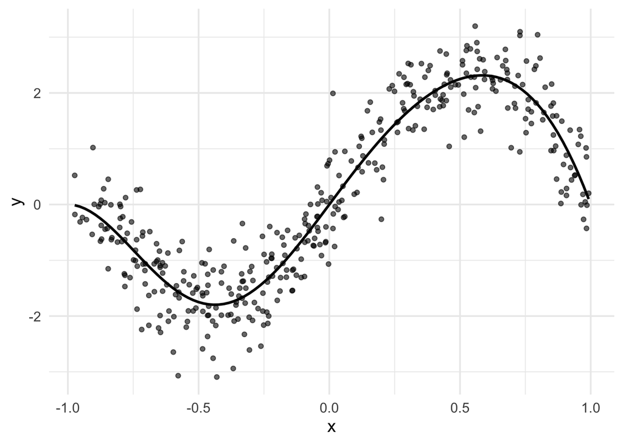

```r
# e.g.
set.seed(1) # remove/change
f <- function(x) 2 * (x^3  + 1) * sin(pi * x)
n <- 400
noise_variance <- 0.5^2
data_full <- data.frame(
  x = runif(n, min = -1, max = 1)
) |>
  mutate(
    true_CEF = f(x),
    y = true_CEF + rnorm(n, sd = sqrt(noise_variance))
  )
ggplot(data_full, aes(x,y)) +
  geom_point(alpha = .6) +
  stat_function(fun = f, size = 1)
```

### Split data

Use some fraction of the sample (e.g. 2/3 or 8/10) as training data and the remainder as validation data. (Hint: `sample(1:n, replace = FALSE)` and look up `?setdiff`)

Note: we need some way to deal with the fact that `loess` cannot `predict` outside the range of the training data. One imperfect solution is to remove any points from the test data that fall outside the range. Another is to remove `NA` values when predicting, i.e. computing MSE using `mean(..., na.rm = TRUE)`. I use `filter()` below to do this.

```r
prop_train <- 8/10
n <- nrow(data_full)
train <- sample(1:n, floor(prop_train*n), replace = FALSE)
test <- setdiff(1:n, train)
data_train <- data_full[train, ]
data_test <- data_full[test, ] |>
  filter(x <= max(data_train$x), x >= min(data_train$x))
c(nrow(data_train), nrow(data_test))
```

```
## [1] 320  80
```

### Fit models

Fit non-linear regression models on the training data using several different values of the complexity/smoothness parameter

```r
model1 <- loess(y ~ x, span = .9, data = data_train)
model2 <- loess(y ~ x, span = .7, data = data_train)
model3 <- loess(y ~ x, span = .5, data = data_train)
model4 <- loess(y ~ x, span = .3, data = data_train)
```

or

```r
spans <- c(seq(from = .1, to = .9, by = .1), .95)
models <- map(spans, function(s)
  loess(y ~ x, span = s, data = data_train)
)
```

### Validate

Compute the prediction error (MSE) on the training data and test data and compare these at each value of the complexity parameter.

```r
MSE_train <- c(
  mean(residuals(model1)^2),
  mean(residuals(model2)^2),
  mean(residuals(model3)^2),
  mean(residuals(model4)^2))

MSE_test <- c(
  mean((predict(model1, newdata = data_test) - data_test$y)^2),
  mean((predict(model2, newdata = data_test) - data_test$y)^2),
  mean((predict(model3, newdata = data_test) - data_test$y)^2),
  mean((predict(model4, newdata = data_test) - data_test$y)^2)
)

MSEs <- cbind(MSE_train, MSE_test)
rownames(MSEs) <- c(.9, .7, .5, .3)
MSEs
```

```
##     MSE_train  MSE_test
## 0.9 0.3152103 0.4023180
## 0.7 0.2628378 0.3593220
## 0.5 0.2553749 0.3500151
## 0.3 0.2509596 0.3431282
```

or

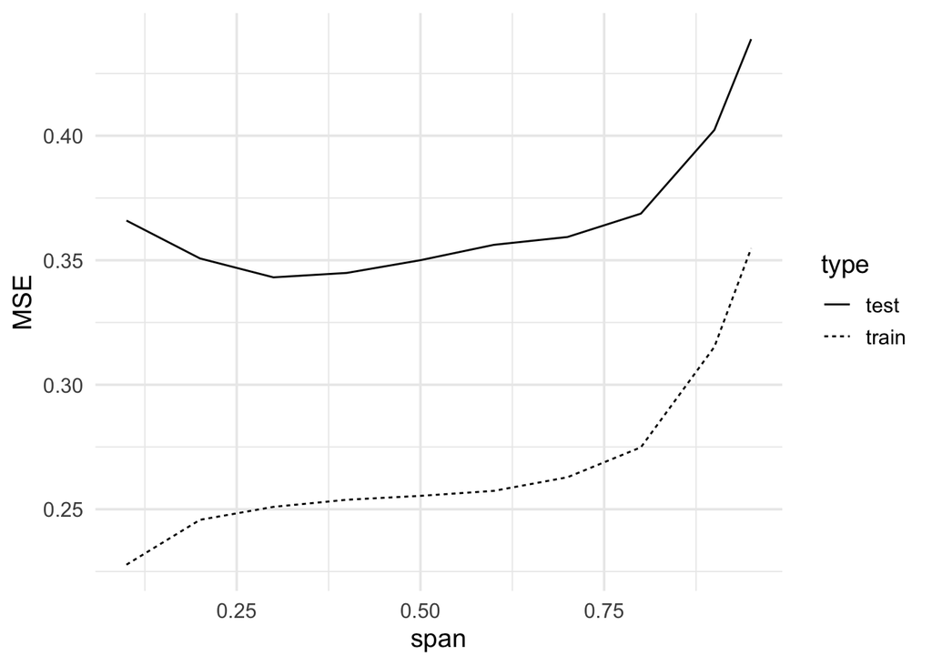

```r
all_MSEs <- map_dfr(models, function(m) {
  data.frame(train = mean(residuals(m)^2),
  test = mean((predict(m, newdata = data_test) - data_test$y)^2))
}) |>
  mutate(span = spans)
all_MSEs |>
  pivot_longer(!span, names_to = "type", values_to = "MSE") |>
  ggplot(aes(span, MSE, linetype = type)) + geom_line()
```

**Question**: What do you notice about the comparison?

Usually the test error is larger than the training error

**Question**: Which value of the complexity parameter has the lowest validation error?

Roughly .3 for this data

### Distribution shift / OOD generalization / bias

Generate new test data that has a different distribution from the original data.

**Question**: How many different ways can you think of to change the distribution of the new data?

Change distribution of `x`, change true CEF `f`, change distribution of errors.

```r
data_OOD <- data.frame(
    x = runif(n, min = -1, max = 1)
) |>
  mutate(
    true_CEF = f(x) ,#- .6 * sin(pi * x),
    y = true_CEF + rnorm(n, sd = 1.2 * sqrt(noise_variance))
  ) |>
  filter(x <= max(data_train$x), x >= min(data_train$x))
```

Compute MSE on new OOD data

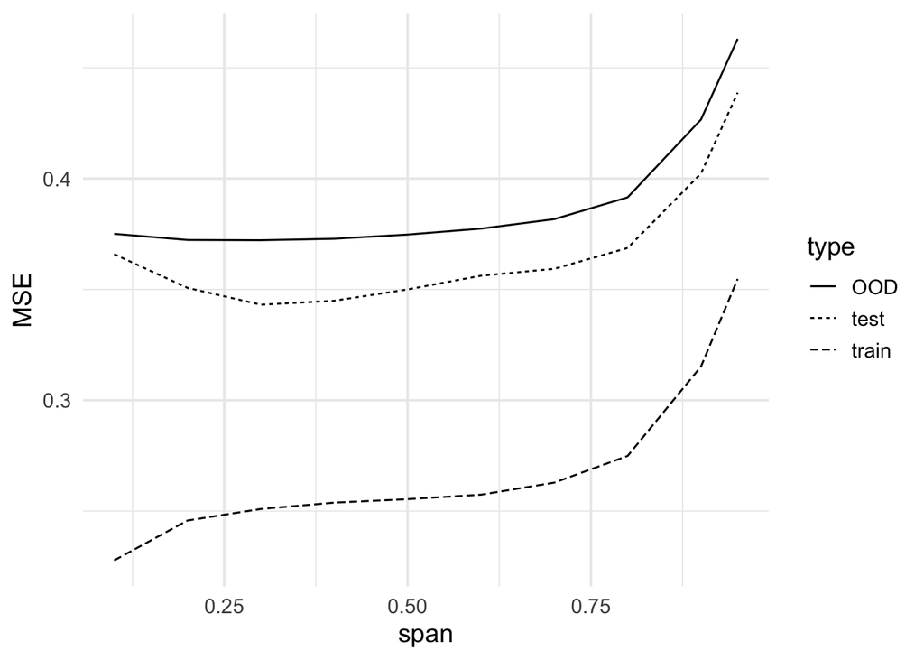

```r
map_dfr(models, function(m) {
  data.frame(OOD = mean((predict(m, newdata = data_OOD) - data_OOD$y)^2))
}) |>
  cbind(all_MSEs) |>
  pivot_longer(!span, names_to = "type", values_to = "MSE") |>
  ggplot(aes(span, MSE, linetype = type)) + geom_line()
```

**Question**: Can you make the MSE on new data systematically higher? How about lower?

Yes to both, changing the distribution by, for example, decreasing/increasing the variance of the noise (and keeping everything else the same).

**Question**: Does the complexity level that minimizes test error also minimize the OOD test error?

No, not in general (unless the new distribution is close enough to the original one). It’s possible for a model with low test error to have high error on OOD data.

## Stochastic gradient descent

#### Complexity measure: optimization time

Now repeat the previous steps in this new data generation and model fitting context. Start by copy/pasting code from a [previous notebook](https://ml4ds.com/weeks/05-optimization/notebooks/SGD_complete.html).

### Generate data

Simulate data from a linear model.

```r
set.seed(1) # comment/uncomment/change this
n <- 200
p <- 400
X <- matrix(rnorm(n*p), nrow = n)
beta <- rpois(p, lambda = 1.5)
SGD_starting_beta <- rnorm(p) # generate once
#beta <- sample(c(-1, 0, 0, 1), p, replace = TRUE)
sigma <- 2
y <- X %*% beta + rnorm(n, sd = sigma)
# sparsity level
sum(beta != 0)
```

```
## [1] 305
```

### Split data

```r
prop_train <- 7/10
n <- nrow(X)
train <- sample(1:n, floor(prop_train*n), replace = FALSE)
test <- setdiff(1:n, train)
X_train <- X[train, ]
X_test <- X[test, ]
y_train <- y[train]
y_test <- y[test]
```

### Fit models

Fit linear regression models using SGD on the training data, with more than one epoch.

Starting from the SGD implementation in the notebook linked above, be careful to change `X`, `y`, and `n` to something like `X_train`, `y_train`, and `nrow(X_train)`. You should also update `SGD_path` to track the test loss.

Finally, be sure to change the `least_squares_loss` function to use `mean` instead of `sum` so that the result doesn’t depend on the sizes of the training/test data.

```r
# Loss function
least_squares_loss <- function(x, y, beta) {
  residuals <- y - x %*% beta
  mean(residuals^2)
}
# Gradient of the loss function
least_squares_gradient <- function(x, y, beta) {
  residuals <- y - x %*% beta
  -2 * t(x) %*% residuals
}
# SGD setup
epochs <- 50
batch_size <- 20 # for batch SGD
gamma <- 0.9
beta_hat <- SGD_starting_beta # generated once above
#beta_hat <- rnorm(p) # random start
num_batches <- ceiling(nrow(X_train)/batch_size)
steps <- epochs * num_batches
SGD_path <- data.frame(step = 1:steps,
                       epoch = numeric(steps),
                       gamma = numeric(steps),
                       train_loss = numeric(steps),
                       test_loss = numeric(steps),
                       MSE = numeric(steps),
                       beta_hat_norm = numeric(steps),
                       gradient_norm = numeric(steps))
# Main SGD loop
start_time <- Sys.time()
step <- 1
for (epoch in 1:epochs) {
  # Pass over sample in a random order each time
  shuffled_indices <- sample(1:nrow(X_train), nrow(X_train), replace = TRUE)

  for (batch in 1:num_batches) {
    batch_start <- 1 + batch_size * (batch - 1)
    batch_end <- min(batch_size * batch, nrow(X_train))
    batch_indices <- shuffled_indices[batch_start:batch_end]
   # Mini-batch
    X_batch <- X_train[batch_indices, , drop = FALSE]
    y_batch <- y_train[batch_indices]
    # Update beta_hat
   gradient_batch <- least_squares_gradient(X_batch, y_batch, beta_hat)
   gradient_norm <- sqrt(sum(gradient_batch^2))
   beta_hat <- beta_hat - gamma^epoch * gradient_batch / (1e-8 + gradient_norm)
   train_loss <- least_squares_loss(X_train, y_train, beta_hat)
   test_loss <- least_squares_loss(X_test, y_test, beta_hat)

  # Store algorithm path information
  SGD_path[step, ] <- c(step,
                        epoch,
                        gamma^epoch,
                        train_loss,
                        test_loss,
                        mean((beta_hat - beta)^2),
                        sqrt(sum(beta_hat^2)),
                        gradient_norm)
  step <- step + 1
  }
}

print(Sys.time() - start_time)
```

```
## Time difference of 0.3693879 secs
```

### Validate

Use the current estimate at the end of each epoch to compute the prediction error (MSE) on the training data and test data and compare them.

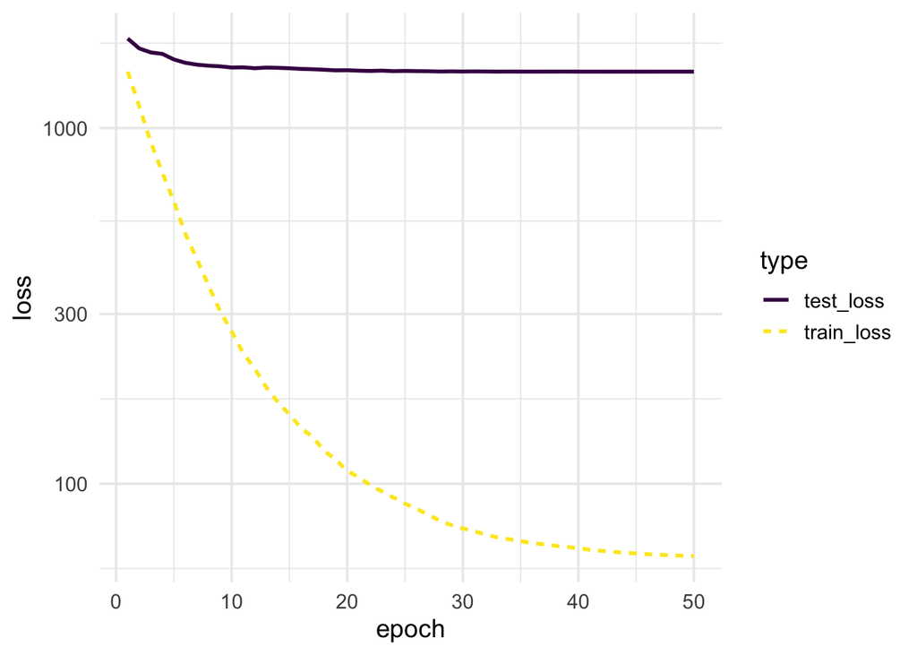

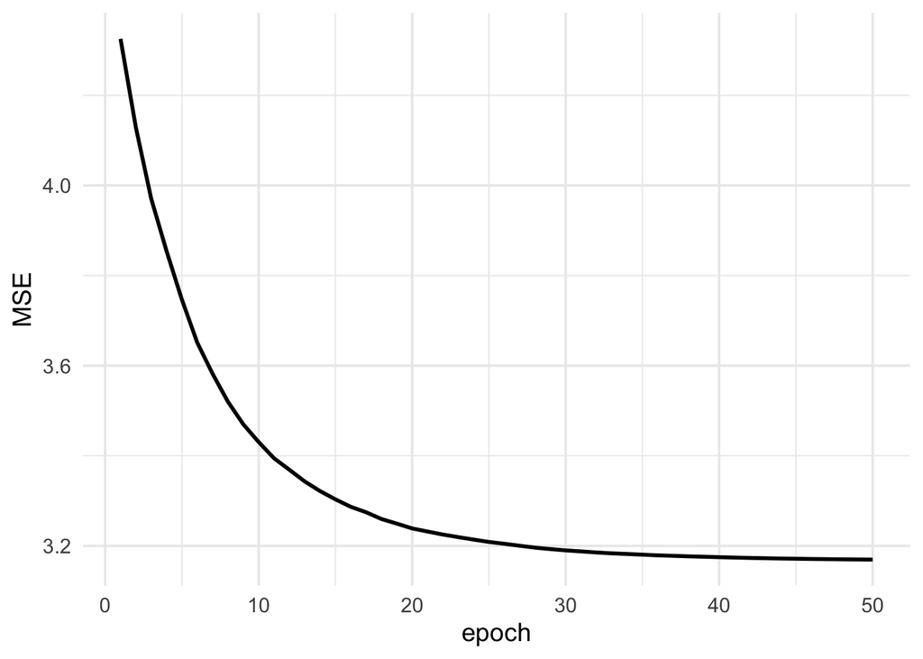

**Question**: Do you observe any relationships between training error, test error, and MSE?

Test error tends to decrease slower than training error and practically stops decreasing before training error does the same. The shape of the MSE curve might be somewhere between: it seems to keep decreasing after test error has stopped, and then to stop decreasing before training error.

### Optional: SGD loss on OOD data

Generate new test data with a slightly different distribution.

```r
# Can also change dist. of X
X_OOD <- matrix(rnorm(n*p, sd = 1), nrow = n)
#beta_OOD <- beta
beta_OOD <- beta + rnorm(p, sd = .1)
# Set small coefficients to zero
#beta_OOD[which(abs(beta) <= 1)] <- 0
# Make some small coefficients larger
#beta_OOD[which(abs(beta) <= 1)] <- 2 * beta_OOD[which(abs(beta) <= 1)]
# noise sd reduced
y_OOD <- X_OOD %*% beta_OOD + rnorm(n, sd = 1.0 * sigma)
```

Copy/paste the previous SGD implementation and modify it to also compute the OOD loss.

```
## Time difference of 0.604388 secs
```

Plot the results

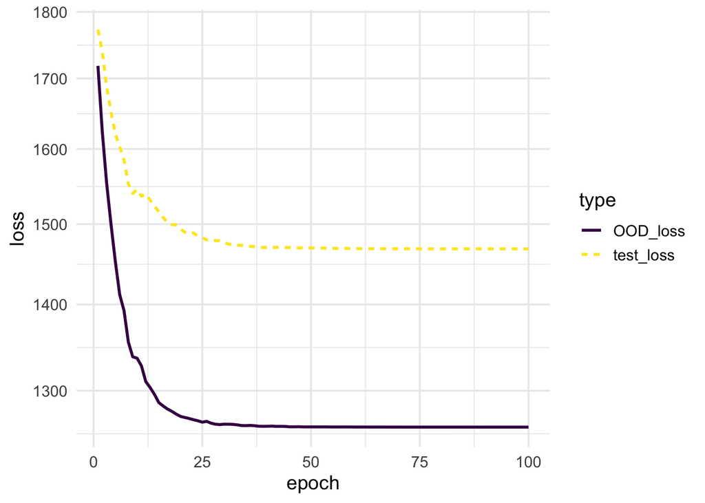